# Reproducible research assignment 1 on Activity monitoring data

Karin

Sunday, May 17, 2015

Loading and preprocessing the data

```r
setwd("C:/Users/Karin-PC/Downloads/repdata_data_activity")
data_complete <- read.csv("activity.csv")
library("dplyr")
```

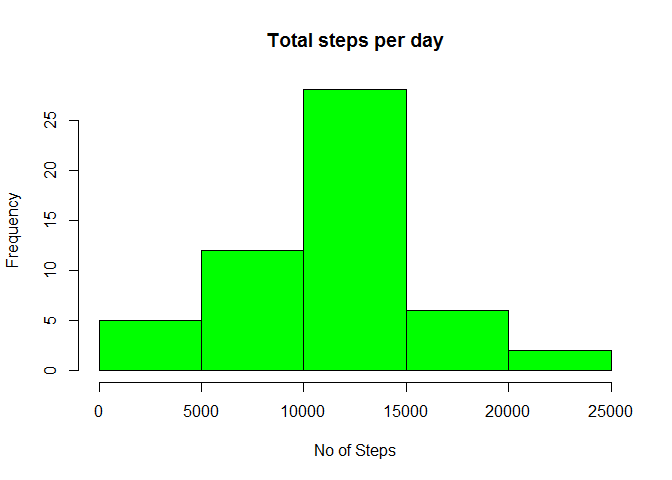

```r
exNa <- filter(data_complete, steps >= 0)
#Calculate the total number of steps taken per day
by_day <- exNa %>% group_by(date)
y <- by_day %>% summarise(Total.steps = sum(steps))
#Make a histogram of the total number of steps taken each day
hist(y$Total.steps, col = 'green', main = "Total steps per day", ylab = "Frequency", xlab = "No of Steps")
```

```r
x <- median(y$Total.steps, na.rm = FALSE)
print(x)
```

```
## [1] 10765
```

What is the average daily activity pattern? This chunk of code is using the dataset, excluding the NA’s, grouping it by interval into morning, midday or evening. This grouping is then used to calculate the mean steps per interval

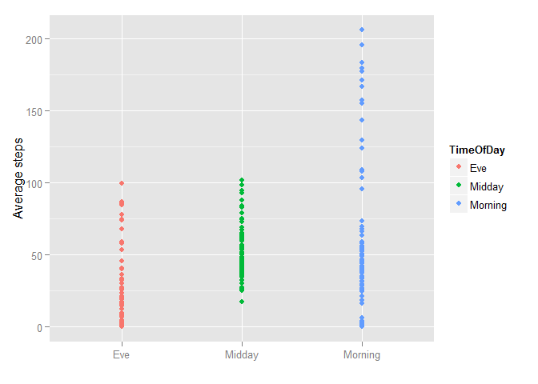

```r
data_excl <- mutate(exNa, TimeOfDay = ifelse(interval < 1200, "Morning", ifelse(interval >= 1200 & interval < 1800, "Midday", "Eve")))
by_cat <- data_excl %>% group_by(TimeOfDay, interval)
z <- by_cat %>% summarise(Ave.steps = mean(steps))
#add leading 0's
z <- mutate(z, int2 = sprintf("%04d", as.numeric(interval)))
z <- select(z, TimeOfDay, Ave.steps, int2)
#Make a time series plot x- interval y - mean
library(ggplot2)
qplot(TimeOfDay, Ave.steps, data = z, color = TimeOfDay, ylab = "Average steps", xlab = "")
```

```r
#which 5min interval on ave contains max no of steps
by_int <- exNa %>% group_by(interval)
Ave <- by_int %>% summarise(Ave.steps = mean(steps))
Ave <- mutate(Ave, interval = sprintf("%04d", as.numeric(interval)))
Ave <- arrange(Ave, desc(Ave.steps))
q2 <- Ave[1,]
print(q2)
```

```
## Source: local data frame [1 x 2]
##
##   interval Ave.steps
## 1     0835  206.1698
```

Inputing missing values The strategy that is used to fill the missing values is based on the average per 5min interval. Dataset temp is only collecting NA values from the complete dataset and then transformed to add the same columns as the dataset, excluding NA’s to allow for a seamless merge later on.

```r
testNA <- sum(is.na(data_complete$steps))
print(testNA)
```

```
## [1] 2304
```

```r
#Strategy > use the ave per 5min interval to fill the missing data
temp <- filter(data_complete, is.na(steps))
temp <- mutate(temp, interval = sprintf("%04d", as.numeric(interval)))
temp <- full_join(temp, Ave, by = "interval")
temp <- select(temp, date, interval, Ave.steps)
temp <- rename(temp, steps = Ave.steps)
temp <- mutate(temp, TimeOfDay = ifelse(interval < 1200, "Morning", ifelse(interval >= 1200 & interval < 1800, "Midday", "Eve")))
data_excl <- mutate(data_excl, interval = sprintf("%04d", as.numeric(interval)))
#Create a new dataset that is equal to the original dataset but with the missing #data filled in
all_data <- full_join(temp, data_excl, by = NULL)
```

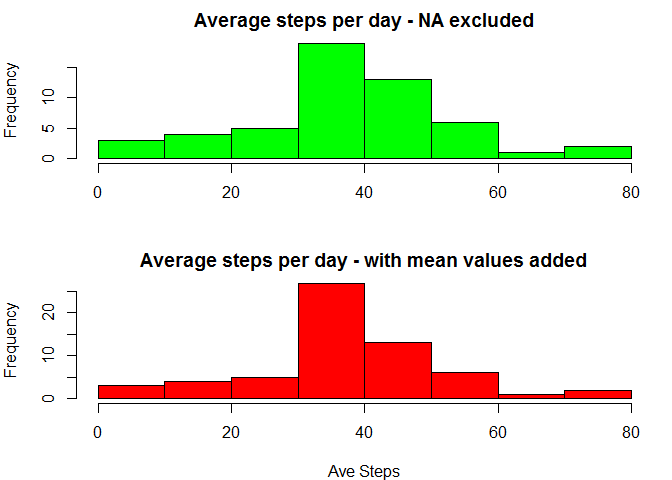

```r
by_day2 <- all_data %>% group_by(date)
y <- by_day %>% summarise(Ave.steps = mean(steps))
y2 <- by_day2 %>% summarise(Ave.steps = mean(steps))
par(mfrow = c(2, 1), mar = c(4, 4, 2, 1))
hist(y$Ave.steps, col = 'green', main = "Average steps per day - NA excluded", ylab = "Frequency", xlab = "")
hist(y2$Ave.steps, col = 'red', main = "Average steps per day - with mean values added", ylab = "Frequency", xlab = "Ave Steps")
```

Are there differences in activity patterns between weekdays and weekends? Ensure that the date is in the correct format before the “DayofWeek” function were used to assign day of week and then use this to determine if its was a weekday or weekend.

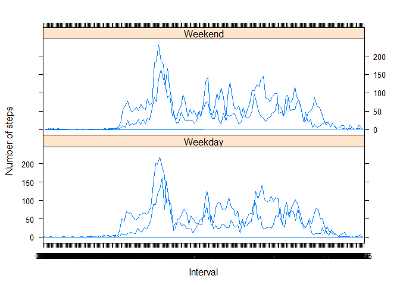

```r
all_data <- mutate(all_data, date = as.Date(date))
all_data <- mutate(all_data, DayOfWeek = weekdays(date))
all_data <- mutate(all_data, day_tp = ifelse(DayOfWeek == "Sunday", "Weekend", ifelse(DayOfWeek == "Saturday", "Weekend", "Weekday")))
by_week <- all_data %>% group_by(day_tp, interval)
x <- by_week %>% summarise(Ave.steps = mean(steps))

library("lattice", lib.loc="C:/Program Files/R/R-3.2.0/library")
x$day_tp <- factor(x$day_tp)
x$interval <- factor(x$interval)
xyplot(Ave.steps ~ interval | levels(day_tp),
   data = x,
   type = "l",
   xlab = "Interval",
   ylab = "Number of steps",
   layout=c(1,2))
```